# sklearn.datasets.boston

## ボストン住宅価格データセット

Software Design 2018/9 ITエンジニアのための統計学入門 第1特集 第5章

```python
%matplotlib inline
import numpy as np
import pandas as pd
from sklearn.datasets import load_boston
boston = load_boston()
X = boston.data
y = boston.target
feature_names = boston.feature_names
```

```python
feature_names
```

```
array(['CRIM', 'ZN', 'INDUS', 'CHAS', 'NOX', 'RM', 'AGE', 'DIS', 'RAD',
       'TAX', 'PTRATIO', 'B', 'LSTAT'], dtype='<U7')
```

- CRIM : 人口1人当たりの犯罪発生率
- ZN : 25000平方フィートより大きい住宅の割合
- INDUS : 町ごとの小売業以外の商業の割合
- CHAS : チャールズ川沿いに面しているかどうか (川沿いなら1、それ以外は0)
- NOX : 窒素酸化物 (Nitric OXides) の濃度
- RM : 住居あたりの平均部屋数
- AGE : 1940年より前に建てられた住居の割合
- DIS : ボストン市の5つの雇用施設からの重み付き距離
- RAD : 高速道路へのアクセスしやすさの指標
- TAX : ＄10,000あたりの不動産税率の総計
- PTRATIO : 町の生徒と教師の比率
- B : 黒人の人数(Bk)の割合 (計算式 : $1000(\mathrm{Bk} - 0.63)^2$)
- LSTAT : 地位の低い職業に就いている割合 (%)

```python
df = pd.DataFrame(X, columns=feature_names)
df.head()
```

|  | CRIM | ZN | INDUS | CHAS | NOX | RM | AGE | DIS | RAD | TAX | PTRATIO | B | LSTAT |
| --- | --- | --- | --- | --- | --- | --- | --- | --- | --- | --- | --- | --- | --- |
| 0 | 0.00632 | 18.0 | 2.31 | 0.0 | 0.538 | 6.575 | 65.2 | 4.0900 | 1.0 | 296.0 | 15.3 | 396.90 | 4.98 |
| 1 | 0.02731 | 0.0 | 7.07 | 0.0 | 0.469 | 6.421 | 78.9 | 4.9671 | 2.0 | 242.0 | 17.8 | 396.90 | 9.14 |
| 2 | 0.02729 | 0.0 | 7.07 | 0.0 | 0.469 | 7.185 | 61.1 | 4.9671 | 2.0 | 242.0 | 17.8 | 392.83 | 4.03 |
| 3 | 0.03237 | 0.0 | 2.18 | 0.0 | 0.458 | 6.998 | 45.8 | 6.0622 | 3.0 | 222.0 | 18.7 | 394.63 | 2.94 |
| 4 | 0.06905 | 0.0 | 2.18 | 0.0 | 0.458 | 7.147 | 54.2 | 6.0622 | 3.0 | 222.0 | 18.7 | 396.90 | 5.33 |

describe() で基本統計量を取得する

- count : データ数
- mean : 平均値
- std : 標準偏差
- min : 最小値
- 25% : 最小から数えて25%の値
- 50% : 最小から数えて50%の値 (中央値)
- 75% : 最小から数えて75%の値
- max : 最大値

```python
df.describe()
```

|  | CRIM | ZN | INDUS | CHAS | NOX | RM | AGE | DIS | RAD | TAX | PTRATIO | B | LSTAT |
| --- | --- | --- | --- | --- | --- | --- | --- | --- | --- | --- | --- | --- | --- |
| count | 506.000000 | 506.000000 | 506.000000 | 506.000000 | 506.000000 | 506.000000 | 506.000000 | 506.000000 | 506.000000 | 506.000000 | 506.000000 | 506.000000 | 506.000000 |
| mean | 3.613524 | 11.363636 | 11.136779 | 0.069170 | 0.554695 | 6.284634 | 68.574901 | 3.795043 | 9.549407 | 408.237154 | 18.455534 | 356.674032 | 12.653063 |
| std | 8.601545 | 23.322453 | 6.860353 | 0.253994 | 0.115878 | 0.702617 | 28.148861 | 2.105710 | 8.707259 | 168.537116 | 2.164946 | 91.294864 | 7.141062 |
| min | 0.006320 | 0.000000 | 0.460000 | 0.000000 | 0.385000 | 3.561000 | 2.900000 | 1.129600 | 1.000000 | 187.000000 | 12.600000 | 0.320000 | 1.730000 |
| 25% | 0.082045 | 0.000000 | 5.190000 | 0.000000 | 0.449000 | 5.885500 | 45.025000 | 2.100175 | 4.000000 | 279.000000 | 17.400000 | 375.377500 | 6.950000 |
| 50% | 0.256510 | 0.000000 | 9.690000 | 0.000000 | 0.538000 | 6.208500 | 77.500000 | 3.207450 | 5.000000 | 330.000000 | 19.050000 | 391.440000 | 11.360000 |
| 75% | 3.677083 | 12.500000 | 18.100000 | 0.000000 | 0.624000 | 6.623500 | 94.075000 | 5.188425 | 24.000000 | 666.000000 | 20.200000 | 396.225000 | 16.955000 |
| max | 88.976200 | 100.000000 | 27.740000 | 1.000000 | 0.871000 | 8.780000 | 100.000000 | 12.126500 | 24.000000 | 711.000000 | 22.000000 | 396.900000 | 37.970000 |

scatter_matrix() で相関関係を調べる

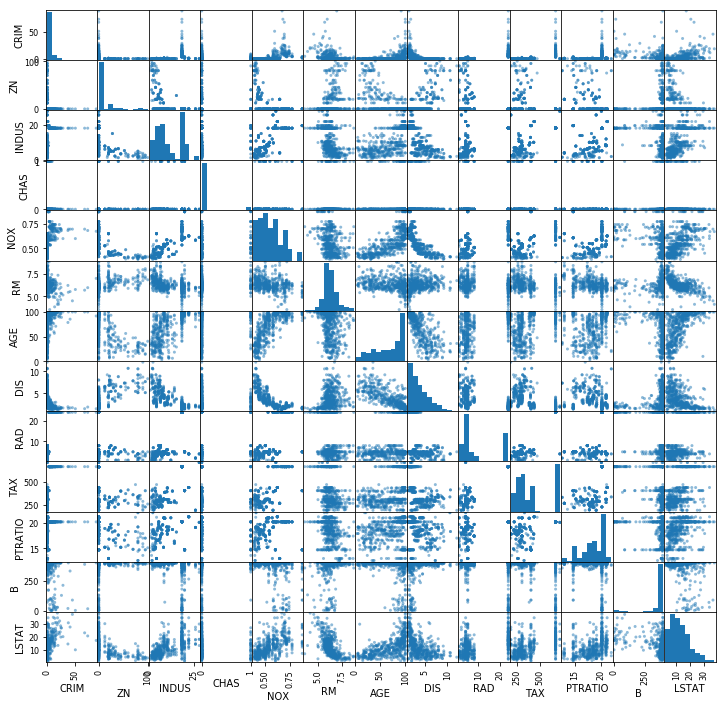

```python
_ = pd.plotting.scatter_matrix(df, figsize=(12,12))
```

df.hist() でヒストグラムの作成

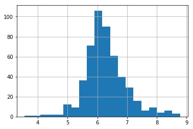

```python
_ = df['RM'].hist(bins=20)
```

describe() で住居あたりの平均部屋数の基本統計量を求める

```python
df['RM'].describe()
```

```
count    506.000000
mean       6.284634
std        0.702617
min        3.561000
25%        5.885500
50%        6.208500
75%        6.623500
max        8.780000
Name: RM, dtype: float64
```

df.plot.scatter() で散布図の描画 (xが部屋数、yが住宅価格)

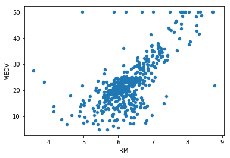

```python
df1 = df['RM']
df2 = pd.DataFrame(y, columns=['MEDV'])

data_RM_MEDV = pd.concat([df1, df2], axis=1) # データの結合
_ = data_RM_MEDV.plot.scatter(x='RM', y='MEDV')
```

train_test_split() で説明変数と目的変数から学習データとテストデータを作成する

```python
from sklearn.model_selection import train_test_split
X = df.RM.to_frame()
y = pd.DataFrame(y, columns=['MEDV'])
X_train, X_test, y_train, y_test = train_test_split(X, y, test_size=0.3, random_state=0)
```

LinearRegression() で線形回帰をフィットさせて、スコア（線形回帰がどれくらいデータに当てはまっているか）を測定する。

```python
from sklearn.linear_model import LinearRegression

lr = LinearRegression()
lr.fit(X_train, y_train)

score = lr.score(X_test, y_test)
print('score:', score)
```

```
score: 0.43514364832115193
```

predict() で線形回帰モデルによる予測をする

```python
room_count = 6
price = lr.predict([[room_count]])
print('平均%d部屋の住宅価格は%.1fです' % (room_count, price))
```

```
平均6部屋の住宅価格は19.9です
```

mean_squared_error() で平均二乗誤差を求めてモデルの評価を行う

```python
from sklearn.metrics import mean_squared_error

y_pred = lr.predict(X_test)
mse = mean_squared_error(y_test, y_pred)
print('平均二乗誤差 : %.3f' % mse)
```

```
平均二乗誤差 : 47.033
```